# Introduction to Data Manipulation in R - PART 2

### Indexing with `tidyverse`

Indexing with numbers is a very old school way. There is nothing wrong with it, but it can be hard to understand and read. At least you may not be able to decipher the meaning right away if someone tries to do some fancy indexing.

With the help of `tidyverse`, indexing can be much simpler and intuitive. It may not be very easy to grasp at the very beginning, but you will love it.

```r
library(tidyverse)
ICEdata <- read_csv("ICE1_Data.csv")
ICEdata
```

| DBN | Quality_Review_Score | Progress_Rpt_10-11 | Student_Progress_10-11 | graduation 2010-11 | college enroll 2010-11 |
| --- | --- | --- | --- | --- | --- |
| 01M292 | Developing | C | C | 0.563 | 0.519 |
| 01M448 | Developing | C | B | 0.707 | 0.363 |
| 01M450 | Well Developed | A | B | 0.716 | 0.692 |
| 01M509 | Proficient | C | C | 0.564 | 0.477 |
| 01M539 | Proficient | A | A | 0.953 | 0.870 |
| 01M696 | Well Developed | B | C | 0.976 | 0.957 |
| 02M047 | Proficient | C | D | 0.696 | 0.471 |
| 02M288 | Proficient | A | B | 0.820 | 0.627 |
| 02M294 | Well Developed | B | B | 0.675 | 0.483 |
| 02M296 | Proficient | A | A | 0.793 | 0.560 |

[output cut: 412 more lines]

```r
new_ICE <- select(ICEdata, `DBN`, `Quality_Review_Score`, `Progress_Rpt_10-11`)
new_ICE
```

| DBN | Quality_Review_Score | Progress_Rpt_10-11 |
| --- | --- | --- |
| 01M292 | Developing | C |
| 01M448 | Developing | C |
| 01M450 | Well Developed | A |
| 01M509 | Proficient | C |
| 01M539 | Proficient | A |
| 01M696 | Well Developed | B |
| 02M047 | Proficient | C |
| 02M288 | Proficient | A |
| 02M294 | Well Developed | B |
| 02M296 | Proficient | A |

[output cut: 412 more lines]

*Note.* More frequently, if a dataset only has column names in one word (i.e., no spaces), it is OK to just call the column name with out `` `` ``, but for our case, you need to use`` `` `` to indicate the names of the variables because it contains spaces.

## Data manipulation in `tidyverse`

The `dplyr` package from the `tidyverse` introduces functions that perform some of the most common operations when working with data frames and uses names for these functions that are relatively easy to remember. For instance, to change the data table by adding a new column, we use `mutate`. To filter the data table to a subset of rows, we use `filter`. And previously, we have seen how to use `select` to subset the data by selecting specific columns.

### Adding a column with `mutate`

We want all the necessary information for our analysis to be included in the data table. The function mutate takes the data frame as a first argument and the name and values of the variable as a second argument using the convention name = values. I am just making things up: let’s calculate the college/graduation rate by dividing college enroll rate by graduation rate:

```r
collegeGraduation <- mutate(ICEdata, colllegeGraduationRate = `college enroll 2010-11` / `graduation 2010-11`)
## Move the data table view to the very end to view the newly created variable.
collegeGraduation
```

| DBN | Quality_Review_Score | Progress_Rpt_10-11 | Student_Progress_10-11 | graduation 2010-11 | college enroll 2010-11 | colllegeGraduationRate |
| --- | --- | --- | --- | --- | --- | --- |
| 01M292 | Developing | C | C | 0.563 | 0.519 | 0.9218472 |
| 01M448 | Developing | C | B | 0.707 | 0.363 | 0.5134371 |
| 01M450 | Well Developed | A | B | 0.716 | 0.692 | 0.9664804 |
| 01M509 | Proficient | C | C | 0.564 | 0.477 | 0.8457447 |
| 01M539 | Proficient | A | A | 0.953 | 0.870 | 0.9129066 |
| 01M696 | Well Developed | B | C | 0.976 | 0.957 | 0.9805328 |
| 02M047 | Proficient | C | D | 0.696 | 0.471 | 0.6767241 |
| 02M288 | Proficient | A | B | 0.820 | 0.627 | 0.7646341 |
| 02M294 | Well Developed | B | B | 0.675 | 0.483 | 0.7155556 |
| 02M296 | Proficient | A | A | 0.793 | 0.560 | 0.7061791 |

[output cut: 412 more lines]

Here, I decide to create a new object `collegeGraduation` to store the edited the original ICEdata object. If you don’t do anything: `select(ICEdata, x, y, z)`, your changes won’t be saved. If you choose to save it to the original `ICEdata`: `ICEdata <- select(ICEdata, x, y, z)`, the `ICEdata` will be overwritten. If we load the `ICEdata` again through ’read_csv()`, the original will overwrite our mutated version.

### Filtering

Previously, you have seen the boolean-way of filtering data. It will work, but sometimes can be complicated when you have different conditions.

`filter()` offers a fairly straight forward way to select limited entries based on conditions. Like `select()` and `mutate()`, we can use the unquoted variable names (if they do not contain spaces) from the dataset inside the function and it will know we mean the columns and not objects in the workspace.

```r
filter(ICEdata, `graduation 2010-11` > 0.8)
```

| DBN | Quality_Review_Score | Progress_Rpt_10-11 | Student_Progress_10-11 | graduation 2010-11 | college enroll 2010-11 |
| --- | --- | --- | --- | --- | --- |
| 01M539 | Proficient | A | A | 0.953 | 0.870 |
| 01M696 | Well Developed | B | C | 0.976 | 0.957 |
| 02M288 | Proficient | A | B | 0.820 | 0.627 |
| 02M298 | Well Developed | A | A | 0.915 | 0.796 |
| 02M316 | Proficient | B | C | 0.803 | 0.640 |
| 02M400 | Well Developed | B | C | 0.832 | 0.756 |
| 02M407 | Well Developed | A | A | 0.833 | 0.709 |
| 02M408 | Proficient | B | B | 0.931 | 0.608 |
| 02M411 | Well Developed | A | A | 1.000 | 0.981 |
| 02M412 | Proficient | A | B | 0.964 | 0.774 |

[output cut: 93 more lines]

You can build multiple conditions in the filter function by using boolean operators.

```r
filter(ICEdata, `graduation 2010-11` > 0.8 & `Quality_Review_Score` == "Proficient")
```

| DBN | Quality_Review_Score | Progress_Rpt_10-11 | Student_Progress_10-11 | graduation 2010-11 | college enroll 2010-11 |
| --- | --- | --- | --- | --- | --- |
| 01M539 | Proficient | A | A | 0.953 | 0.870 |
| 02M288 | Proficient | A | B | 0.820 | 0.627 |
| 02M316 | Proficient | B | C | 0.803 | 0.640 |
| 02M408 | Proficient | B | B | 0.931 | 0.608 |
| 02M412 | Proficient | A | B | 0.964 | 0.774 |
| 02M414 | Proficient | A | A | 0.980 | 0.717 |
| 02M420 | Proficient | B | C | 0.824 | 0.695 |
| 03M541 | Proficient | B | B | 0.875 | 0.923 |
| 04M555 | Proficient | A | A | 0.806 | 0.379 |
| 04M610 | Proficient | A | B | 0.984 | 0.982 |

[output cut: 35 more lines]

### The pipe `%>%`

With `dplyr` we can perform a series of operations, for example `select()` and then `filter()`, by sending the results of one function to another using what is called the pipe operator: `%>%`. Some details are included below.

Suppose, We wrote code above to show three variables (Quality Review score, graduation rate, and Student_Progress_10-11) and we need to make sure the graudation rate is above 0.8. To do this, we need defined the intermediate object `new_ICE`, such as this:

```r
new_ICE <- select(ICEdata, `Quality_Review_Score`, `Student_Progress_10-11`, `graduation 2010-11`)

filter(new_ICE, `graduation 2010-11` > 0.8)
```

| Quality_Review_Score | Student_Progress_10-11 | graduation 2010-11 |
| --- | --- | --- |
| Proficient | A | 0.953 |
| Well Developed | C | 0.976 |
| Proficient | B | 0.820 |
| Well Developed | A | 0.915 |
| Proficient | C | 0.803 |
| Well Developed | C | 0.832 |
| Well Developed | A | 0.833 |
| Proficient | B | 0.931 |
| Well Developed | A | 1.000 |
| Proficient | B | 0.964 |

[output cut: 93 more lines]

There is nothing wrong with this approach, but when your task become complicated, you need to create a lot of useless intermediate variables eating up your valuable space. In `dplyr` we can write code that looks more like a description of what we want to do without intermediate objects:

```r
ICEdata %>%
  select(`Quality_Review_Score`, `Student_Progress_10-11`, `graduation 2010-11`) %>%
  filter(`graduation 2010-11` > 0.8)
```

| Quality_Review_Score | Student_Progress_10-11 | graduation 2010-11 |
| --- | --- | --- |
| Proficient | A | 0.953 |
| Well Developed | C | 0.976 |
| Proficient | B | 0.820 |
| Well Developed | A | 0.915 |
| Proficient | C | 0.803 |
| Well Developed | C | 0.832 |
| Well Developed | A | 0.833 |
| Proficient | B | 0.931 |
| Well Developed | A | 1.000 |
| Proficient | B | 0.964 |

[output cut: 93 more lines]

This line of code is equivalent to the two lines of code above. What is going on here?

In general, the pipe sends the result of the left side of the pipe to be the first argument of the function on the right side of the pipe. Here is a very simple example:

```r
16 %>% sqrt()
```

```
## [1] 4
```

We can continue to pipe values along:

```r
16 %>% sqrt() %>% log2()
```

```
## [1] 2
```

The above statement is equivalent to `log2(sqrt(16))`.

Remember that the pipe sends values to the first argument, so we can define other arguments as if the first argument is already defined:

```r
16 %>% sqrt() %>% log(base = 2)
```

```
## [1] 2
```

Therefore, when using the pipe with data frames and dplyr, we no longer need to specify the required first argument since the dplyr functions we have described all take the data as the first argument.

For readability purposes, I like to break the line after each `%>%`, but you can also write it in one single line like this:

```r
ICEdata %>% select(`Quality_Review_Score`, `Student_Progress_10-11`, `graduation 2010-11`) %>% filter(`graduation 2010-11` > 0.8)
```

| Quality_Review_Score | Student_Progress_10-11 | graduation 2010-11 |
| --- | --- | --- |
| Proficient | A | 0.953 |
| Well Developed | C | 0.976 |
| Proficient | B | 0.820 |
| Well Developed | A | 0.915 |
| Proficient | C | 0.803 |
| Well Developed | C | 0.832 |
| Well Developed | A | 0.833 |
| Proficient | B | 0.931 |
| Well Developed | A | 1.000 |
| Proficient | B | 0.964 |

[output cut: 93 more lines]

Note that the pipe works well with functions where the first argument is the input data. Functions in tidyverse packages like `dplyr` have this format and can be used easily with the pipe.

## Combine datasets

In previous section, we have seen simple dataset manipulations. Here we are going to discuss how to combine datasets in R.

Some of the most interesting studies of data come from combining different data sources. These operations can involve anything from very straightforward concatenation of two different datasets, to more complicated database-style joins and merges that correctly handle any overlaps between the datasets. First let’s look at a few simple examples of concatenation in R.

In R, concatenation can be done fairly simply with `c()`. You have seen that previously. If you have a series of elements and you use `c` to group them.

```r
v <- c(1,4,4,3,2,2,3)
v
```

```
## [1] 1 4 4 3 2 2 3
```

For example, if you want to attach one more element to its end, the process is identical:

```r
c(v, 9)
```

```
## [1] 1 4 4 3 2 2 3 9
```

Alternatively, you can use `append()` to put the new variable at the very end.

```r
append(v, 9)
```

```
## [1] 1 4 4 3 2 2 3 9
```

For `matrix` or `data frame`, or concatenating multiple `vector`s, we can use functions such as `rbind()` as row binding or `cbind()` as column biding. However, again, this is a very old way of doing things. I will not dive into details here, if you want to read more, here is the documentation: https://stat.ethz.ch/R-manual/R-devel/library/base/html/cbind.html

Luckily, `tidyverse` provides very user-friendly way of joining datasets.

For demonstration purpose, we will install a `nycflights13` to get the buil-in datasets: `flights` and `weather`

```r
# install.packages("nycflights13")
library(nycflights13)
data(flights)
data(weather)
# You can use view(flights) and view(weather) to check out how the dataset looks like.
```

First, we will simplify the datasets by `select()`, and then prepare join the data by two common columns `time_hour` and `origin`.

```r
flights <- flights %>% select(carrier, flight,
                              origin, dest, time_hour)
weather <- weather %>% select(temp, wind_speed, precip, origin, time_hour)
mergeCols <- c("origin", "time_hour")
```

Now, we show how to perform the 4 merges (joins). Try to call each dataset to see how they are different:

```r
left_dplyr  <- left_join(flights,  weather, by = mergeCols)
right_dplyr <- right_join(flights, weather, by = mergeCols)
inner_dplyr <- inner_join(flights, weather, by = mergeCols)
full_dplyr  <- full_join(flights,  weather, by = mergeCols)
```

A few figures might help you figure it out:

- **Example of left_join():**

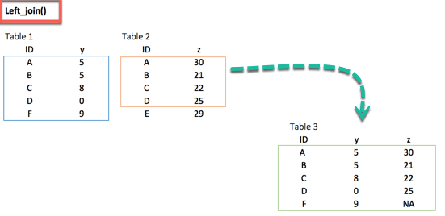

- **Example of right_join():**

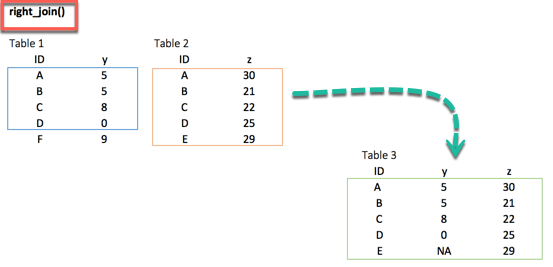

- **Example of inner_join():**

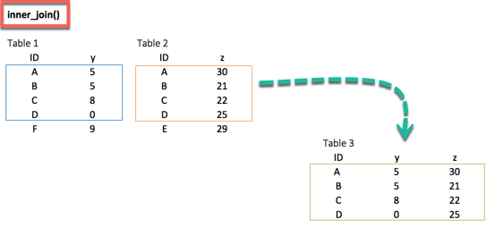

- **Example of full_join():**

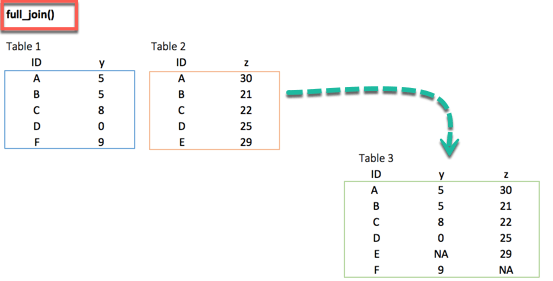

## Aggregate and group data

An important part of exploratory data analysis is summarizing data. The average and standard deviation are two examples of widely used summary statistics. More informative summaries can often be achieved by first splitting data into groups. In this section, we cover two new `tidyverse` verbs that make these computations easier: `summarize` and `group_by`. We learn to access resulting values using the pull function.

### `summarize()`

The `summarize()` function in `tidyverse` provides a way to compute summary statistics with intuitive and readable code. We start with a simple example in `ICEdata`.

```r
g <- ICEdata %>%
  filter(`Quality_Review_Score` == "Proficient") %>%
  summarise(average = mean(`graduation 2010-11`, na.rm = TRUE),
            standardDeviation = sd(`graduation 2010-11`, na.rm = TRUE))
g
```

| average | standardDeviation |
| --- | --- |
| 0.7295541 | 0.1359464 |

Let’s break this down a little bit: (1) First we filter the data by `Quality_Review_Score` and make sure we only include `"Proficient"` Schools. (2) Then we summarize the `graduation 2010-11` into two variables: `average` and `standardDeviation` (here you can name your variable anything you like, it is just the variable name shown on the top of the table), then we call `mean()` and `sd()` to calculate the mean and standard deviation respectively. (3) For both mean() and sd(), we need to specify a parameter called `na.rm=TRUE` to make sure the calculation results do not include `NA`. `NA` is a very tricky null value in R. We need to pay extra attention to them. Read more here: https://stats.idre.ucla.edu/r/faq/how-does-r-handle-missing-values/(4) The pipeline will print out a 1x2 table with both average and standard deviation of the graduation 2010-11 data from the proficient schools.

```r
g$average
```

```
## [1] 0.7295541
```

### group_by

Simple aggregations only gives you a flavor of your dataset, but often we would prefer to aggregate conditionally on some label or index: this is implemented in the so-called `group_by` operation. The name “group by” comes from a command in the `SQL` database language and it is very commonly implemented in many other languages as well.

`groupby` generally follows three steps: *split, apply, and combine*:

- The *split* step involves breaking up and grouping a DataFrame depending on the value of the specified key.
- The *apply* step involves computing some function, usually an aggregate, transformation, or filtering, within the individual groups.
- The *combine* step merges the results of these operations into an output array.

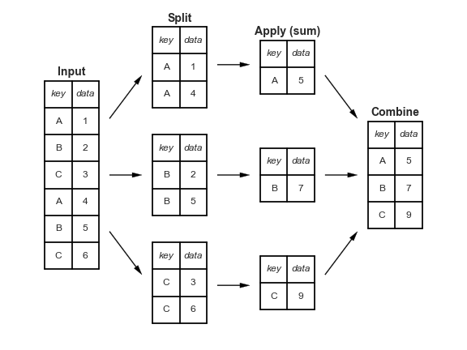

These steps can certainly be done seperatedly and manually (who wants that???). The power of the `group_by` is that it abstracts away and automate these steps: you just need to thinks about the operation as a whole.

```r
ICEdata %>% group_by(Quality_Review_Score)
```

| DBN | Quality_Review_Score | Progress_Rpt_10-11 | Student_Progress_10-11 | graduation 2010-11 | college enroll 2010-11 |
| --- | --- | --- | --- | --- | --- |
| 01M292 | Developing | C | C | 0.563 | 0.519 |
| 01M448 | Developing | C | B | 0.707 | 0.363 |
| 01M450 | Well Developed | A | B | 0.716 | 0.692 |
| 01M509 | Proficient | C | C | 0.564 | 0.477 |
| 01M539 | Proficient | A | A | 0.953 | 0.870 |
| 01M696 | Well Developed | B | C | 0.976 | 0.957 |
| 02M047 | Proficient | C | D | 0.696 | 0.471 |
| 02M288 | Proficient | A | B | 0.820 | 0.627 |
| 02M294 | Well Developed | B | B | 0.675 | 0.483 |
| 02M296 | Proficient | A | A | 0.793 | 0.560 |

[output cut: 412 more lines]

```r
ICEdata %>%
  group_by(Quality_Review_Score) %>%
  summarize(GraduationAverage = mean(`graduation 2010-11`, na.rm = TRUE),
            CollegeEnrollAverage = mean(`college enroll 2010-11`, na.rm = TRUE))
```

| Quality_Review_Score | GraduationAverage | CollegeEnrollAverage |
| --- | --- | --- |
| Developing | 0.6330189 | 0.4028298 |
| Outstanding (only an option in 2007-8) | 0.8643333 | 0.7476667 |
| Proficient | 0.7295541 | 0.5212081 |
| Underdeveloped | 0.5496667 | 0.3501667 |
| Underdeveloped with Proficient Features (only an option in 2007-8, 2008-9 and 2009-10) | NaN | NaN |
| Well Developed | 0.8233667 | 0.6258706 |
| NA | 0.6890000 | 0.4420000 |

Common basic summary data methods all can be used here: - `n()`: Total number of items - `first()`, `last()`: First and last item - `mean()`, `median()`: Mean and median - `min()`, `max()`: Minimum and maximum - `sd()`, `var()`: Standard deviation and variance - `mad()`: Mean absolute deviation - `prod()`: Product of all items - `sum()`: Sum of all items These are all methods of `DataFrame` and `Series` objects.

We can summarize multiple variables at a time.

So far we’ve summarized the `Quality_Review_Score` s. Let’s try to add another group `Progress_Rpt_10-11`:

```r
ICEdata %>%
  group_by(`Quality_Review_Score`, `Progress_Rpt_10-11`) %>%
  summarize(count = n())
```

| Quality_Review_Score | Progress_Rpt_10-11 | count |
| --- | --- | --- |
| Developing | A | 4 |
| Developing | B | 11 |
| Developing | C | 19 |
| Developing | D | 16 |
| Developing | F | 3 |
| Developing | NA | 11 |
| Outstanding (only an option in 2007-8) | A | 3 |
| Proficient | A | 48 |
| Proficient | B | 65 |
| Proficient | C | 39 |

[output cut: 12 more lines]

This format is actually not easy to read because they contain some redundancy. `tidyverse` also offers pivot table options to build either long pivot tables with `pivot_longer()` function or wide pivot tables with `pivot_wider()` functions. Here we are not going to expand too much into it, as it is less frequently used. Read more about pivot tables in R here: https://www.storybench.org/pivoting-data-from-columns-to-rows-and-back-in-the-tidyverse/.Alternatively, Python can handle this task a lot faster.

## More data wrangling

There are a lot to digest because data wrangling can be very complicated, and I only covered a tip of iceberg. But, don’t worry, you don’t have to learn everything before you start working. A lot of things will become natural to you as we move forward. The more you practice, the more fluent you will become. There are plenty of tutorials, Q&A, and documentations out there online. Just google them! I am 99% sure that someone has already asked the same question for you at this stage. One good skill to learn is to ask the right question, so that Dr. Google can help you find the best solution. One day, when you reach to the level that your can ask a question that no one has seen before and no one knows how to solve immediately, then congrats, you are a pro now!

For now, here are a couple of data wrangling cheat sheet/tutorial you may want to save:

- [Data transformation with `dplyr` cheatsheet](https://github.com/rstudio/cheatsheets/raw/master/data-transformation.pdf)
- [Data tidying with `tidyr` cheatsheet](https://github.com/rstudio/cheatsheets/raw/master/tidyr.pdf)
- [Introduction to Tidyverse : readr, tibbles, tidyr & dplyr](https://brianward1428.medium.com/introduction-to-tidyverse-7b3dbf2337d5)
- [Data Wrangling with R and data.table - Workshop](https://youtu.be/EdPKcy1WKD0)

## Your Tasks for ICE 2

For ICE 2, you may want to:

1. follow my tutorial and learn how to manipulate data in R
2. explore ACA1 and see how ICE2 will inform your ACA1.
3. keep good record of your ICEs. Save the .ipynb files in a same place. You will need them later.